# МК ggplot2

## Разметка осей и переменные

Важнейшие элементы любого графика — это оси. Мы строим двумерные графики, поэтому и оси у нас две — как учили в школе, *x (горизонтальная ось, ось абсцисс)* и *y (вертикальная ось, ось ординат)*.

Чтобы задать оси графика потребуется отдельная функция. Она называется `aes()`, и в общем задает *эстетики* графика.

### Эстетики

Итак, конкретнее об эстетиках. Иначе говоря, это то *форматирование, которое связано с данными*. Или еще один способ понимания — *способы отображения переменных из датасета*. У функции `aes()` есть ряд параметров, они тоже называются *эстетики*.

Вот список эстетик, которые используются чаще всего: `x`, `y`, `color`, `fill`, `shape`, `size`.

Несложно догадаться, что переменные по осям задаются параметрами `x` и `y`. Что ж, зададим.

Давайте визуализируем связь между временем первого и второго клика.

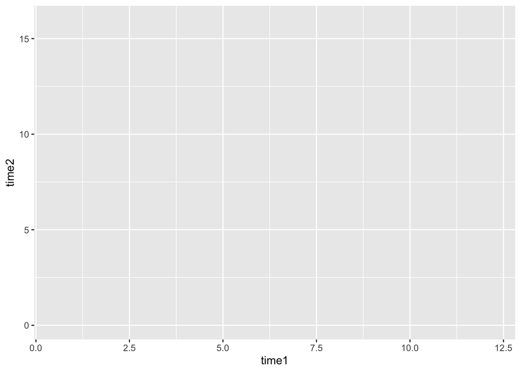

```r
ggplot(data = share, aes(x = time1, y = time2))
```

Так, ну, допустим… А где картинка?

Картинки нет, но `ggplot2` честно отработал свою работу. Мы задали только оси — и он нам разметил их в соответствии с имеющимися в векторах значениях. Больше мы ему ничего не написали. Чтобы всё-таки получить картинку, необходимо указать, как мы хотим отборазим наши переменные.

## Геомы

За то, каким образом будут отображены переменными, а конкретно, какими «геометрическими объектами», отвечает семество функций `geom_*`. Когда мы переходим к этой функции, мы переходим на новый слой. Чтобы это обозначить используется плюсик `+`.

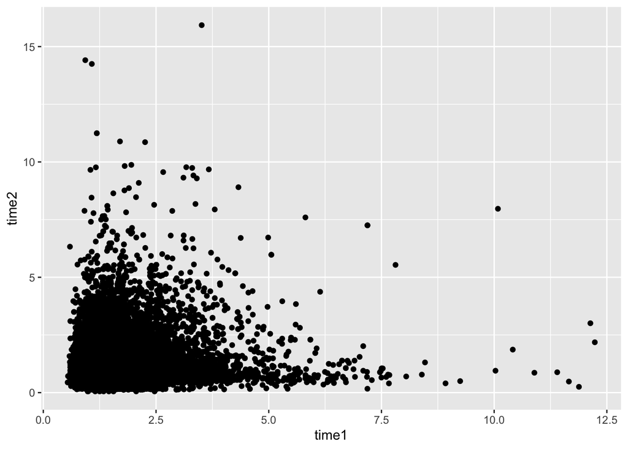

```r
ggplot(data = share, aes(x = time1, y = time2)) +
  geom_point()
```

Мы выбрали точки для отображения переменных, потому что наиболее наглядный вариант отобразить зависимость между двумя переменными. Такой тип графика называется *scatterplot*, или *диаграмма рассеяния*.

Но, вообще-то, можно и получше отобразить закономерность. Как минимум, добавить линию тренда в помощью специального геома:

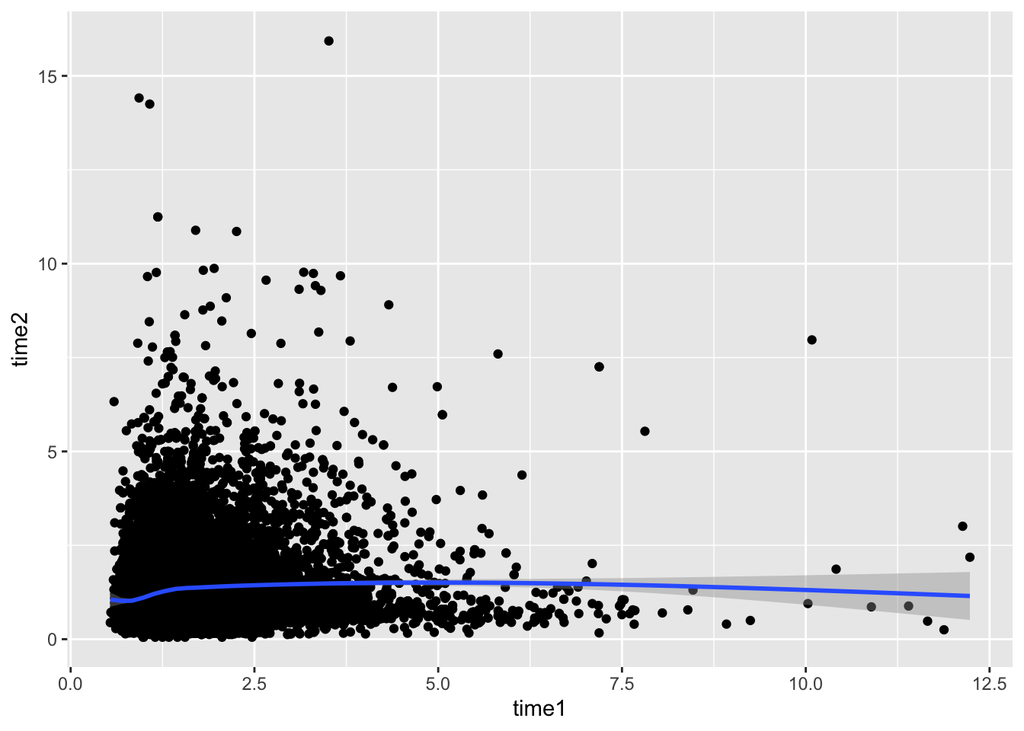

```r
ggplot(data = share, aes(x = time1, y = time2)) +
  geom_point() +
  geom_smooth()
```

Как видите, при добавлении нового «геометрического» способа отображения данных мы добавляем новый слой.

Сейчас мы гораздо отчетливее видим, что тренда собственно никакого и нет. Но мы можем визуализировать ещё более явно. Так как `geom_smooth()` подразумевает «склаживание», оно может происходить с помощью разных методов (используемый метод нам написали в консоль). Мы можем эскплицинто указать метод. Например, использовать линейную модель:

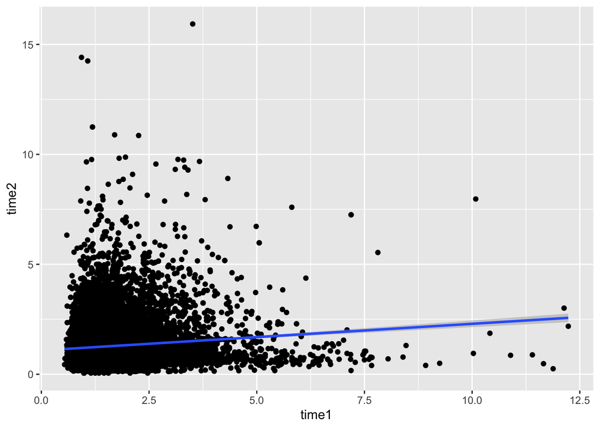

```r
ggplot(data = share, aes(x = time1, y = time2)) +
  geom_point() +
  geom_smooth(method = 'lm')
```

И — ха! — какая-то минимальная связь вроде как есть! Хотя возможно это влияние выбросов (помним, что мы не чистили данные)…

# Группировка по переменной

Чаще всего в практике нас интересует связь между переменными не по всему датасету, а различие в связи между группами. Чтобы посмотреть, что есть интересного, давайте разобьем наши наблюдения на группы по используемой платформе.

Вспомним об эстетиках. Предположим, мы хотим отобразить на графике группы по используемой платформе смартфона с помощью цвета. Для этого есть эстетика `color`, которой необходимо указать переменную, по которой мы будем группировать.

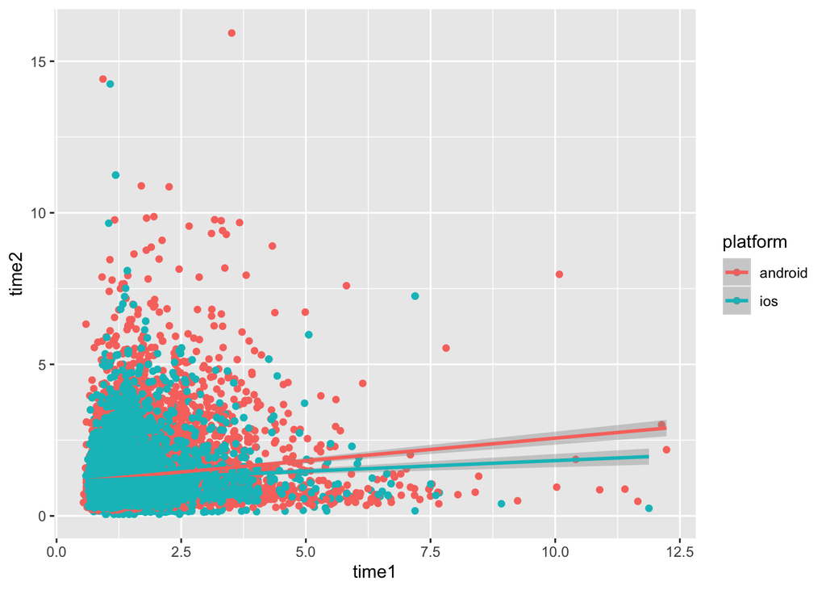

```r
ggplot(data = share, aes(x = time1, y = time2, color = platform)) +
  geom_point() +
  geom_smooth(method = 'lm')
```

Стало видно, что, оказывается, зависимость в двух группах разная (обратите внимание на доверительные зоны линии тренда). Но в левом нижнем углу графика происходит какой-то ад — все смешалось, наложилось, ничего не разобрать. Это можно поправить с помощью аргумента, задающего прозрачность (`alpha`).

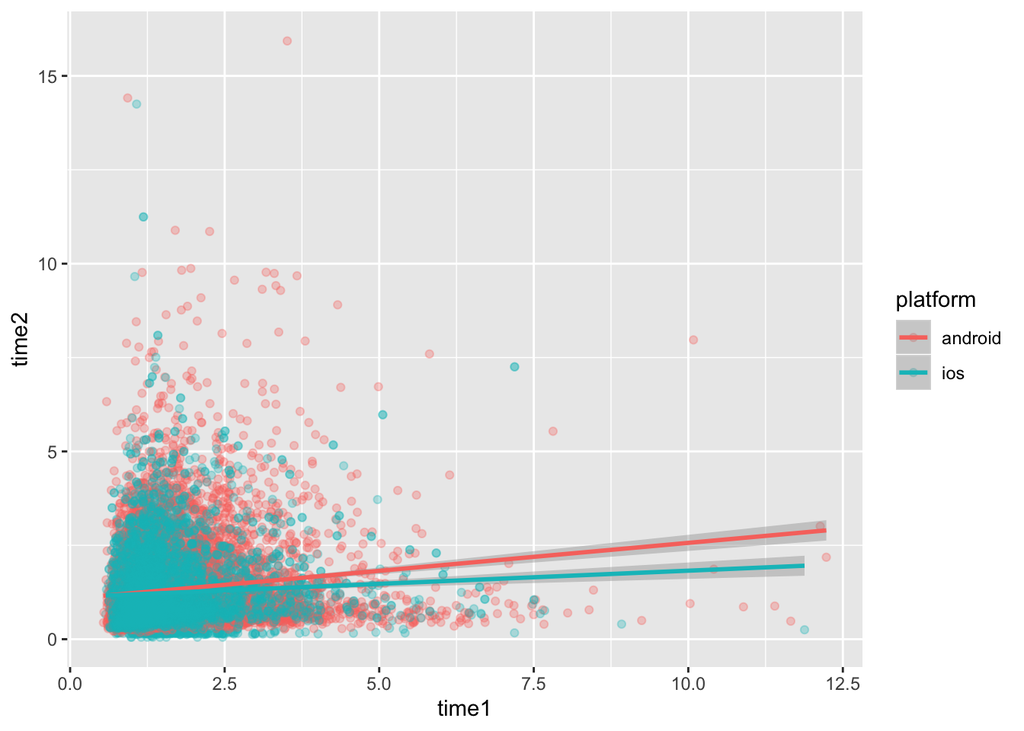

```r
ggplot(data = share, aes(x = time1, y = time2, color = platform)) +
  geom_point(alpha = .3) +
  geom_smooth(method = 'lm')
```

Это не сильно помогло, потому что точек там охренеть как сколько, но как прицнипиальный способ борьбы с «непонятностью» может хорошо работать.

Для группировки можно задать и другую эстетику, например форму точек:

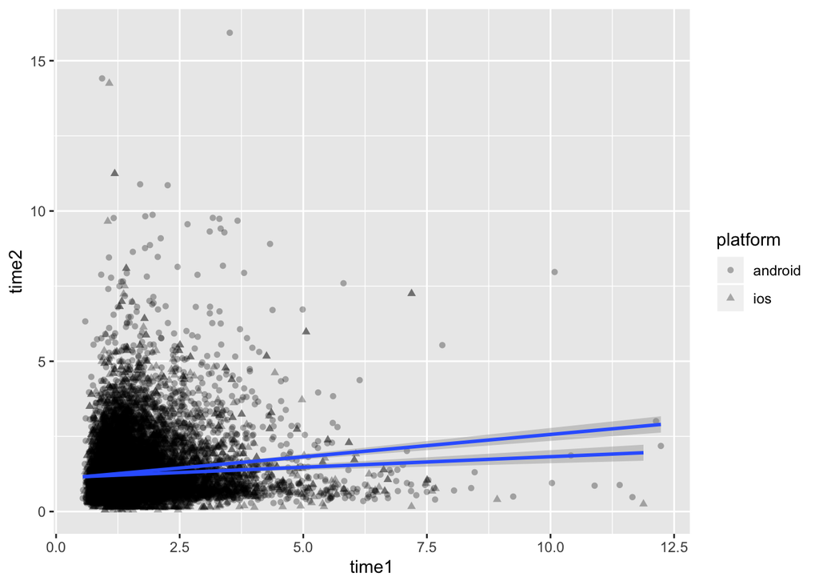

```r
ggplot(data = share, aes(x = time1, y = time2, shape = platform)) +
  geom_point(alpha = .3) +
  geom_smooth(method = 'lm')
```

В данный пример показывает, что не любые способы задания эстетик одинаково хороши. В частности здесь мы потеряли часть информацтивности графика — теперь мы не можем понять, какая линия тренда какой группе наблюдений соответствует. :(

# Графики со встроенной статистической обработкой

Часто бывает так, что мы хотим отобразить не сырые данные, а какие-то посчитанные статистики. Поэтому необходимо сначала предобрадотать данные, получить наобходимые значения и затем на их основе построить график.

Но зачем? Если можно сразу в коде построения графика рассчитать все, что нам нужно! В `ggplot2` уже встроены инструменты простейшей статистический обработки!

Еще раз посмотрим на датасет. У нас есть время первого клика, а также три условия сетсайзов. Наверняка, среднее время реакции (первого клика) будет различаться в этих трех условиях. Давайте это проверим! Но перед этим нам необходимо познакомиться с новым семейством функций `stat_*`.

## Статы (stat_)

Статы и есть те самые встроенные инструенты статистической обработки. Они позволяют прямо в коде графика обсчитать данные и сразу же визуализировать результаты.

> *На самом деле, мы уже сталкивались со встроенными инструментами статистической обработки, ведь что делает `geom_smooth(method = 'lm')`? Не что иное, как визуализирует линейную регрессию, построенную на выбранных данных!*

Наиболее популярная функция из рассматриваемого семейста — `stat_summary()`. С помощью неё мы и будем визуализировать наши средние.

Для начала посмотрим, как у нас написана переменная, по которой мы собоиаремся группировать налюдения:

```r
str(share$setsize)
```

```
##  num [1:16200] 8 8 8 8 8 8 8 8 8 8 ...
```

Видим, что это вектор типа `numeric` и в нем 16200 наблюдений. Нас такая ситуация не устраивает: нам нужен тип `factor`. Чтобы не перезававать при каждом построении графика, перекодируем переменную (и другие, которые нам пригодятся далее) в требуемый вид (используем пакет `dplyr`, встроенный в `tidyverse`).

```r
share %>% mutate(setsize = as.factor(setsize), # перекодирование в фактор
                 platform = as.factor(platform), # перекодирование в фактор
                 trialtype = as.factor(trialtype), # перекодирование в фактор
                 id = as.factor(id), # перекодирование в фактор
                 time1 = time1 * 1000) -> share # перевод в миллисекунды и запись в датафрейм
```

Теперь можем приступить к построению графика. Начнем с базового слоя:

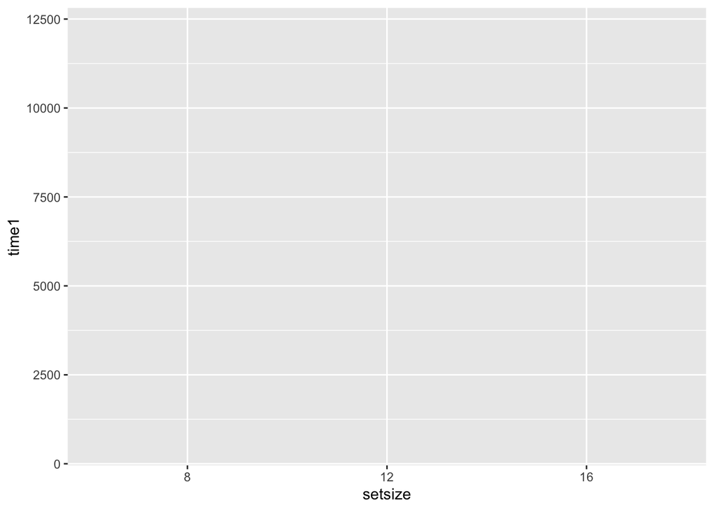

```r
ggplot(share, aes(setsize, time1))
```

Взяли холст, расчертили. По оси *x* у нас будет идти факторная переменная. Теперь добавим средние. Как и полагается, на новый слой.

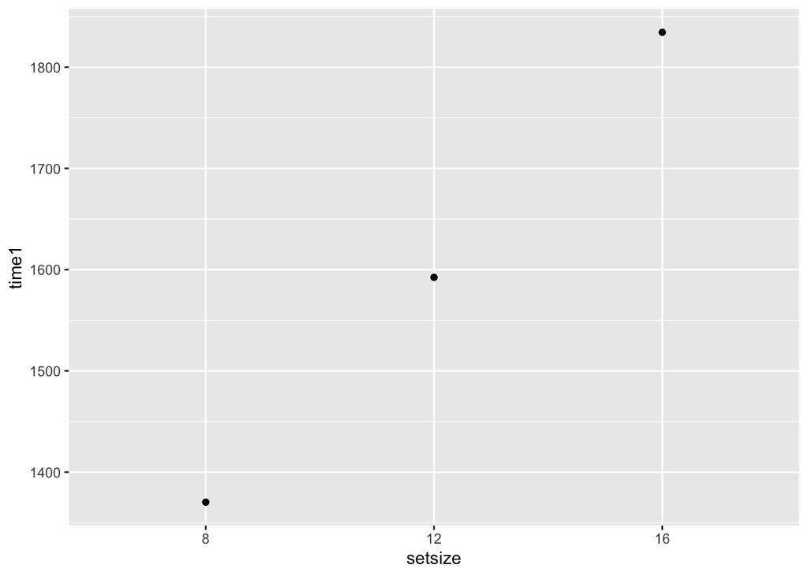

```r
ggplot(share, aes(setsize, time1)) +
  stat_summary(fun.y = mean, geom = 'point')
```

Разберемся, что тут написано. Первый аргумент (`fun.y`) принимает функцию, результат которой будет отложен по оси *y*. В нашем случае это среднее (`mean`). Она будет применена к переменой `time1`, причем наблюдения будут автоматически сгруппированы по интересующим нас группам. Второй аргумент — это уже знакомый нам `geom`, которые отвечает за то, как «геометрически» будут отрисованы знаечния на графике. Наш выбор — точки. Как результат мы наблюдаем то, то хотели.

Однако как мы знаем из статистики, чтобы узнать, есть ли различия между условиями, нам недостаточно только средних значений — необходимы доверительные интервалы. Что ж, отобразим и их.

Добавим новый слой с помощью всё той же функции `stat_summary`, но на этот раз она будет выглядеть немного по-другому:

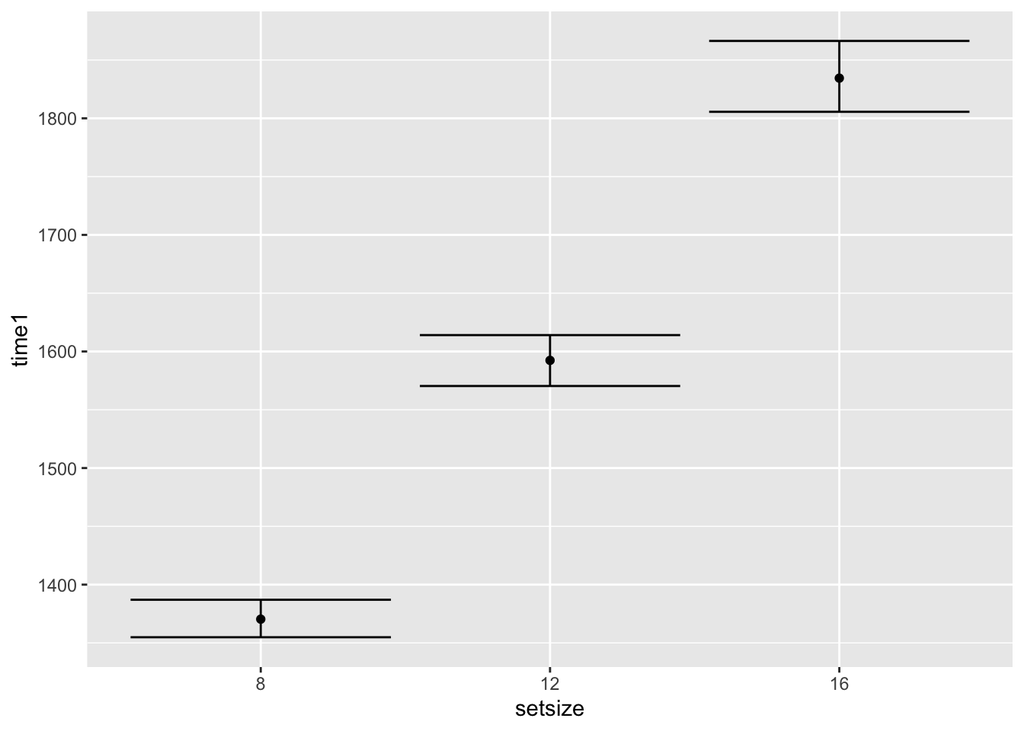

```r
ggplot(share, aes(setsize, time1)) +
  stat_summary(fun.y = mean, geom = 'point') +
  stat_summary(fun.data = mean_cl_boot, geom = 'errorbar')
```

Как мы видим, немного изменился первый аргумент. Это связано с изменением геома. Для отображения доверительных интервалов нам нужен геом `errorbar`, который требует не одно значение, а два — верхнюю и нижнюю границу доверительного интервала. То есть `fun.data` принимает как аргумент что-то типа мини-датафрейма — как раз в таком формате и возвращается результат функции `mean_cl_boot`. Можно посмотреть на её работу отдельно:

```r
mean_cl_boot(share$time1)
```

```
##          y     ymin     ymax
## 1 1599.066 1586.615 1612.509
```

Собственно, вот он датафрейм из одной строки. Здесь три значения, но `errorbar` игронирует первое (оно и его среднее значение) и использует только второе и третье, строя по ним «усы».

Собственно, график почти готов, однако добавим линии, которые будут соединять наши средние. Это не обязательный элемент, но так будет более наглядно отображаться закономерность.

```
## geom_path: Each group consists of only one observation. Do you need to
## adjust the group aesthetic?
```

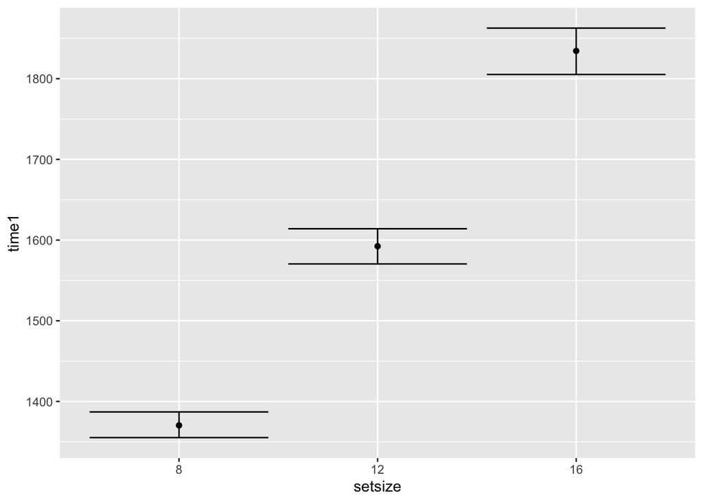

```r
ggplot(share, aes(setsize, time1)) +
  stat_summary(fun.y = mean, geom = 'line') +
  stat_summary(fun.y = mean, geom = 'point') +
  stat_summary(fun.data = mean_cl_boot, geom = 'errorbar')
```

Ага, вроде слой добавили, но ничего не изменилось. Еще и *warning* вылетел. Надо почитать!

`ggplot2` на говорит, что каждая группа у нас содержит одно наблюдение — и он категорически прав, ведь у нас в каждой группе отображается только среднее значение. Из-за этого он не понимает, как ему нужно соединять точки. Надо ему подсказать, что с точки зрения соединения точек у нас всего одна группа, так как мы хотим, чтобы наши среднии были последовательно соединены. Так и запишем (используя аргумент `group`):

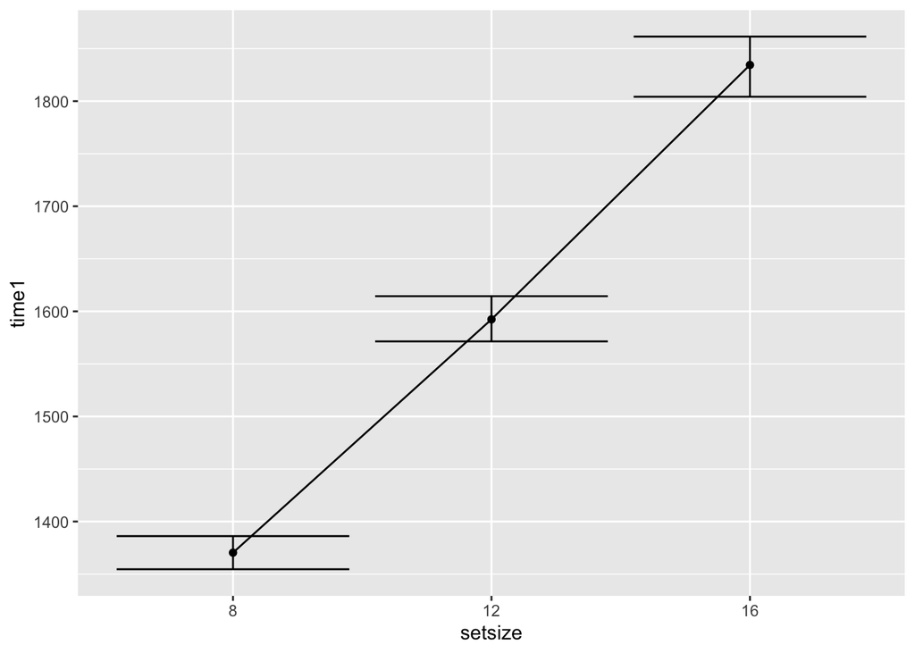

```r
ggplot(share, aes(setsize, time1, group = 1)) +
  stat_summary(fun.y = mean, geom = 'point') +
  stat_summary(fun.data = mean_cl_boot, geom = 'errorbar') +
  stat_summary(fun.y = mean, geom = 'line')
```

Вот такая у нас классная линейная закономерность получилась! Ну, а чего мы ждали — зрительный поиск же…

# Настраиваем график

Как упоминалось выше, `ggplot2` имеет широчайшие возможности кастомизации, в нем можно настроить чуть более, чем всё. Сейчас наш график выглядит хотя и содержательно верно, но с точки зрения дизайна — ну такое. Давайте подправим.

Первое, что бросается в глаза — несообразно огромной ширины *errorbar’ы*. Значит, надо уменьшить ширину. За их ширину отвечает параметр `width`. Ширина задается долями единицы.

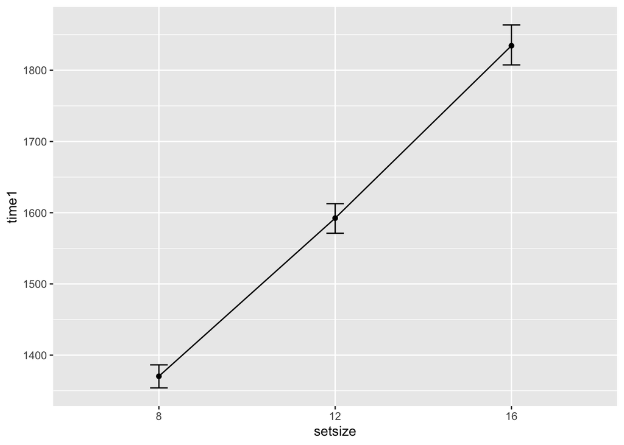

```r
ggplot(share, aes(setsize, time1, group = 1)) +
  stat_summary(fun.y = mean, geom = 'point') +
  stat_summary(fun.data = mean_cl_boot, geom = 'errorbar', width = .1) +
  stat_summary(fun.y = mean, geom = 'line')
```

Вот так вроде хорошо, линии *errorbar’ов* не пересекаются с линией, отображающей общую закономерность.

Что ты еще хотелось подправить? Наверное, сделать акцент на главных смысловых элементах графика. В нашем случае это точки. Давайте сделаем их побольше.

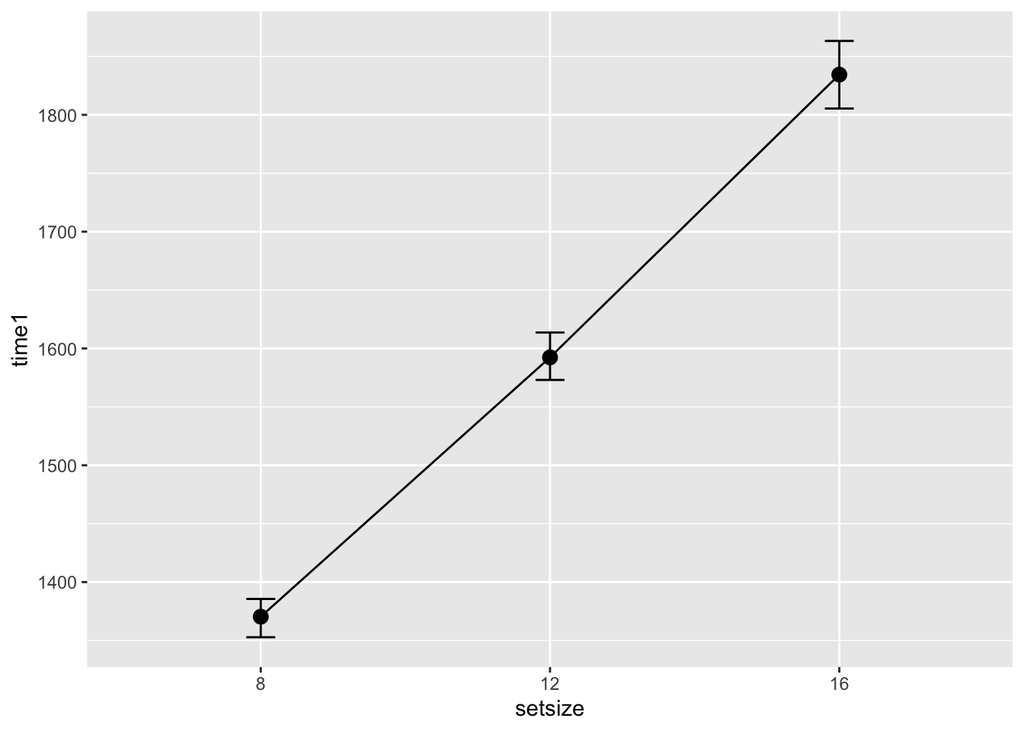

```r
ggplot(share, aes(setsize, time1, group = 1)) +
  stat_summary(fun.y = mean, geom = 'point', size = 3) +
  stat_summary(fun.data = mean_cl_boot, geom = 'errorbar', width = .1) +
  stat_summary(fun.y = mean, geom = 'line')
```

Вот, почти совсем хорошо. Но все-таки «линия тренда» (назовем её так, хотя это не совсем корректно) отвлекает внимание. Она здесь не самая важная. Поработаем с ней. Изменим начертание (`linetype`) и покрасим её в темносерый.

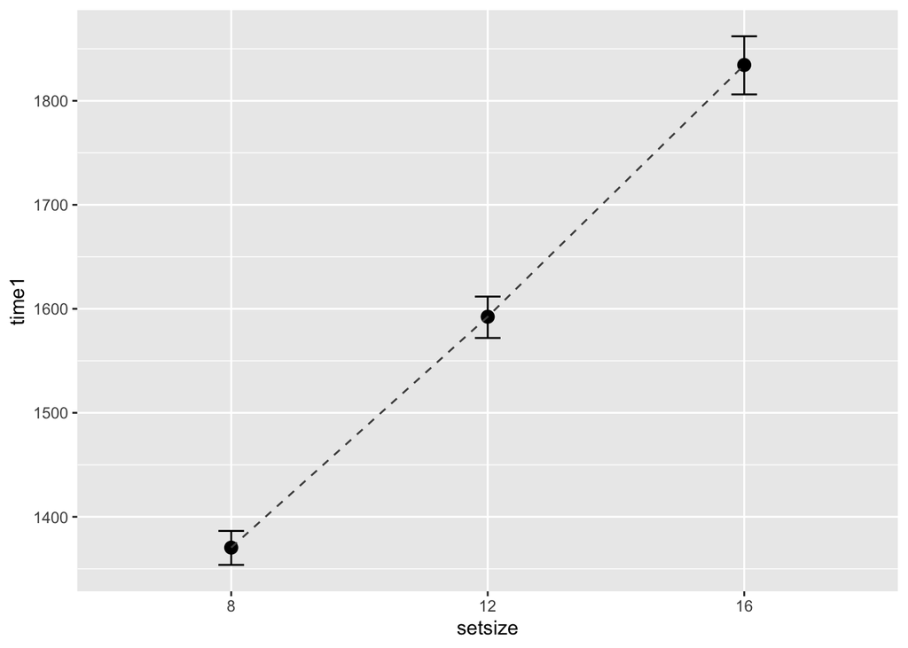

```r
ggplot(share, aes(setsize, time1, group = 1)) +
  stat_summary(fun.y = mean, geom = 'point', size = 3) +
  stat_summary(fun.data = mean_cl_boot, geom = 'errorbar', width = .1) +
  stat_summary(fun.y = mean, geom = 'line', linetype = 'dashed', color = 'gray30')
```

Заметьте, мы задали цвет внутри функции `stat_summary`, хотя ранее указывали его внтури функции `aes()`. Еще раз напомним, что внутри `aes()` задается форматирование, связанное с данными — поэтому когда мы группировали наблюдения с помощью цвета, мы задавали через функцию эстетик. В данном же примере мы задали цвет как бы «извне», он не связан с данными, поэтому мы задаем его вне функции `aes()`.

Все хорошо — да не очень! Теперь серая линия лежит поверх точек. Некрасиво… :( Почему так произошло? Потому что `ggplot2` выполняет команды последовательно как написали: базовый слой → точки → *errorbar’ы* → линия. Чтобы поправить этот баг, надо просто переставить строчки местами: базовый слой → линия → *errorbar’ы* → точки

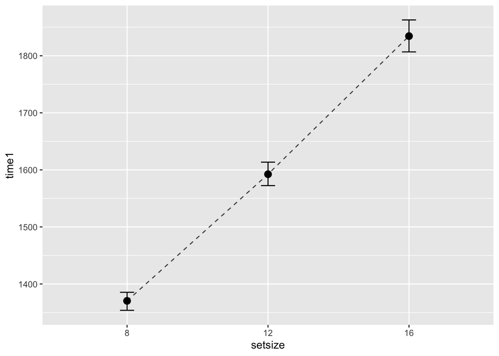

```r
ggplot(share, aes(setsize, time1, group = 1)) +
    stat_summary(fun.y = mean, geom = 'line', linetype = 'dashed', color = 'gray30') +
  stat_summary(fun.data = mean_cl_boot, geom = 'errorbar', width = .1) +
  stat_summary(fun.y = mean, geom = 'point', size = 3)
```

Вот теперь кайф!

## Темы

Но не совсем. Фон какой-то не очень… Дефолтная серая тема в какое-то давнее время была популярна, все выдели что ты крутой и умеешь в ггплот и ваще. Однако со временем это стало *#немодно*, и лучше серой темы избегать, да и требования журналов обычно более строгие.

В `ggplot2` есть ряд встроенных тем, которые задаются через функции семейства `theme_*()`. Наиболее популярные `theme_classic()` и `theme_bw()`. Последнюю мы и будем использовать.

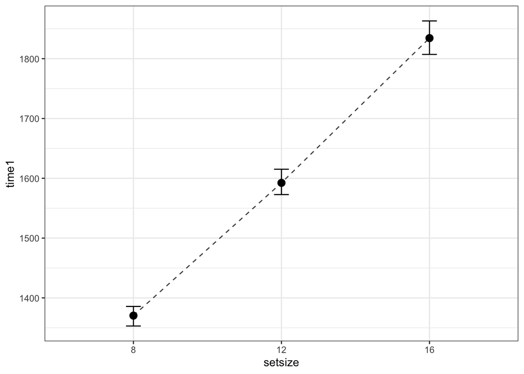

```r
ggplot(share, aes(setsize, time1, group = 1)) +
    stat_summary(fun.y = mean, geom = 'line', linetype = 'dashed', color = 'gray30') +
  stat_summary(fun.data = mean_cl_boot, geom = 'errorbar', width = .1) +
  stat_summary(fun.y = mean, geom = 'point', size = 3) +
  theme_bw()
```

Ах, красота!

## Кастомизация шкал (scale_)

Однако какой-то у нас слишком простой график. Добавим-ка группировку по категориальным переменным. А чтобы график получился осмысленный, предвалительно сабсетнем данные.

```
## geom_path: Each group consists of only one observation. Do you need to
## adjust the group aesthetic?
```

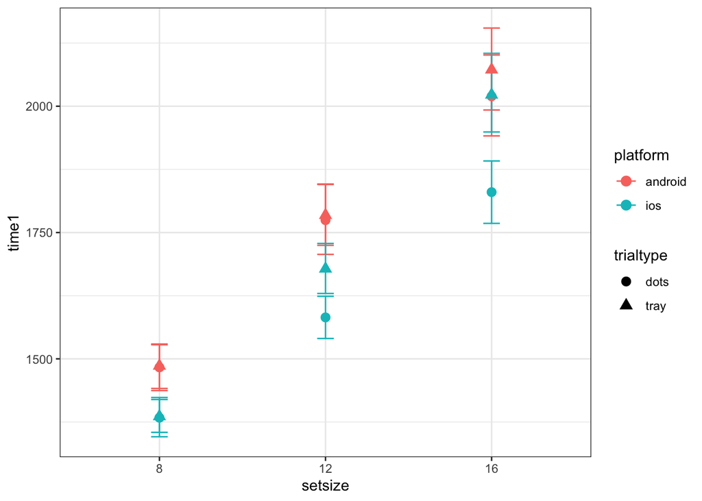

```r
share %>%
  filter(trialtype != 'both') %>%
  ggplot(aes(setsize, time1, color = platform, shape = trialtype)) +
    stat_summary(fun.y = mean, geom = 'line', linetype = 'dashed', color = 'gray30') +
  stat_summary(fun.data = mean_cl_boot, geom = 'errorbar', width = .1) +
  stat_summary(fun.y = mean, geom = 'point', size = 3) +
  theme_bw()
```

Уф… Ну, групировка прошла успешно, уже хорошо, однако отображение хромает. Надо немного раздвинуть точки относительно друг друга с отдельных категория, так как сейчас опи явно друг на друга налезают. Для этого есть аргумент `position`, который принимает результат выполнения функции `position_dodge()` (если и другие `position_*()`, но мы не будем на них останавливаться).

Чтобы упростить код, заведем переменную `pd`, в которую сохраним результаты выполнения функции `position_dodge()` и далее будем передавать эту переменную в аргумент `position`.

```
## geom_path: Each group consists of only one observation. Do you need to
## adjust the group aesthetic?
```

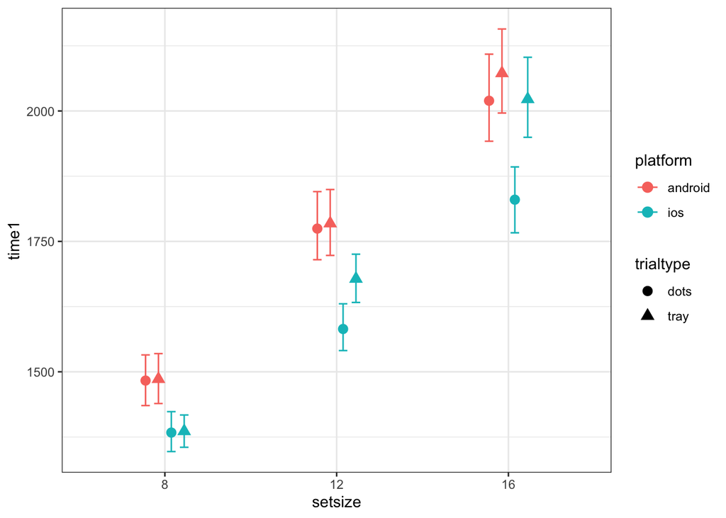

```r
pd <- position_dodge(.3)
share %>%
  filter(trialtype != 'both') %>%
  ggplot(aes(setsize, time1, color = platform, shape = trialtype)) +
    stat_summary(fun.y = mean, geom = 'line', linetype = 'dashed', color = 'gray30', position = pd) +
  stat_summary(fun.data = mean_cl_boot, geom = 'errorbar', width = .2, position = pd) +
  stat_summary(fun.y = mean, geom = 'point', size = 3, position = pd) +
  theme_bw()
```

Точки раздвинулись — круто! Но у нас есть строчка про линии, но они не отрисовываются. С такой проблемой мы уже сталкивались и знаем, как её принципиально решить — задать аргумент `group`. Но как? Ведь теперь у нас не одна группа, а два фактора, в каждой из которых две субгруппы — итого четыре.

Для такой ситуации есть функция `interaction()`, которая возвращает все уровни взаимодействия факторов.

```r
interaction(share$trialtype, share$platform)
```

Результат её работы можно передать в аргумент `group`, и все заработает.

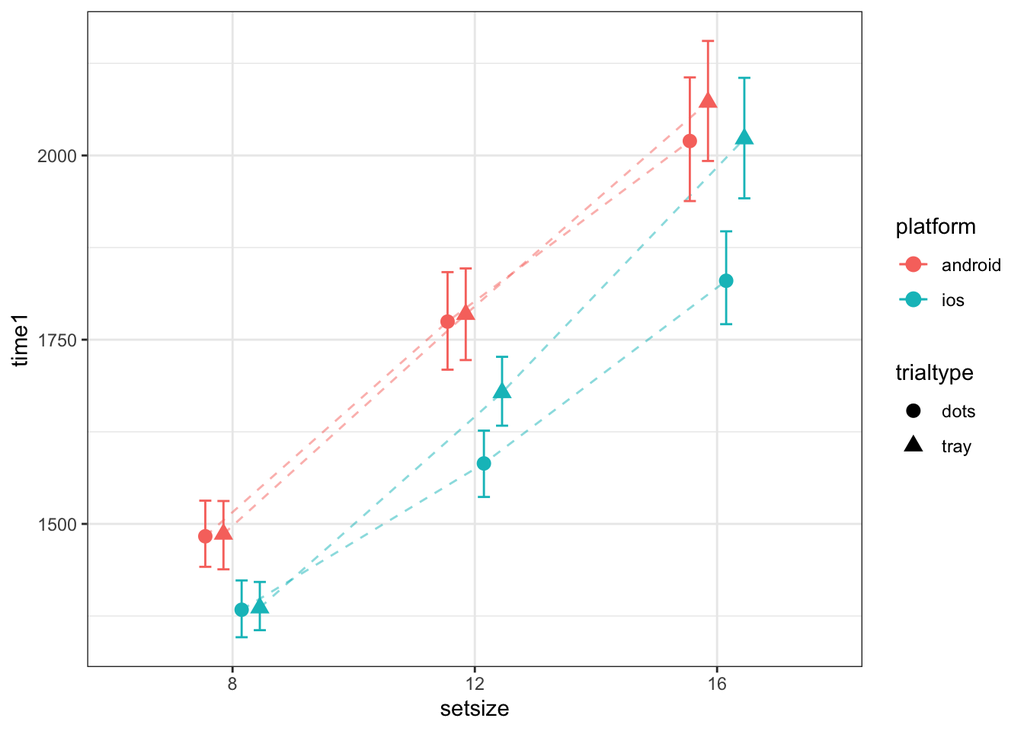

```r
pd <- position_dodge(.3)
share %>%
  filter(trialtype != 'both') %>%
  ggplot(aes(setsize, time1, group = interaction(trialtype, platform), color = platform, shape = trialtype)) +
    stat_summary(fun.y = mean, geom = 'line', linetype = 'dashed', position = pd, alpha = .5) +
  stat_summary(fun.data = mean_cl_boot, geom = 'errorbar', width = .2, position = pd) +
  stat_summary(fun.y = mean, geom = 'point', size = 3, position = pd) +
  theme_bw()
```

Сразу уберем аргумент `color` из строки про линии и добавим прозрачность (`alpha`).

Мы задали отображение групп цветом и формой точек, но шкалы которые используются дефолтные, уже всем успевшие надоесть. Надо бы их поправить.

Для того, чтобы кастомизировать используемые шкалы, есть ряд функций семейства `scale_*()`. Мы познакомимся с некоторыми из них. Для начала изменим цвета.

В `R` можно задавать цвета через [названия](https://github.com/angelgardt/mk_ggplot2/blob/master/Rcolor.pdf) или [HEX](https://www.w3schools.com/colors/colors_hexadecimal.asp) кодировку. Будем использовать названия.

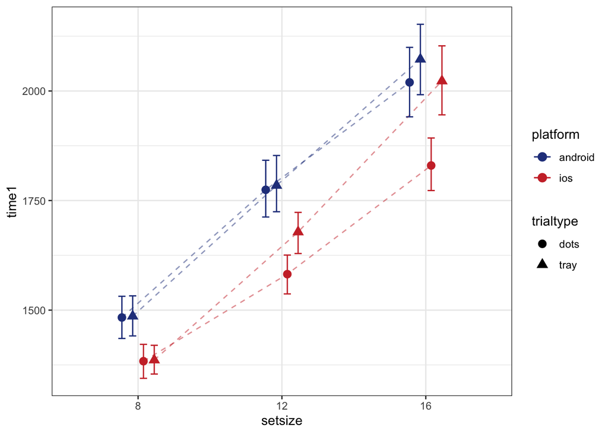

```r
pd <- position_dodge(.3)
share %>%
  filter(trialtype != 'both') %>%
  ggplot(aes(setsize, time1, group = interaction(trialtype, platform), color = platform, shape = trialtype)) +
    stat_summary(fun.y = mean, geom = 'line', linetype = 'dashed', position = pd, alpha = .5) +
  stat_summary(fun.data = mean_cl_boot, geom = 'errorbar', width = .2, position = pd) +
  stat_summary(fun.y = mean, geom = 'point', size = 3, position = pd) +
  theme_bw() +
  scale_color_manual(values = c('royalblue4', 'brown3'))
```

Здесь мы используем функцию `scale_color_manual()`, чтобы задать значения цвета вручную. Используя **обязательный** аргумент `values` мы передаем вектор названий цветов, которые хотим использовать. Вуаля! Красuво!

Теперь — форма. У нас круг и треугольник. Допустим, мы хотим использовать только «угловатые» фигуры и заменить круг на квадрат. Для этого есть `scale_shape_manual()`, которая работает аналогично предыдущей.

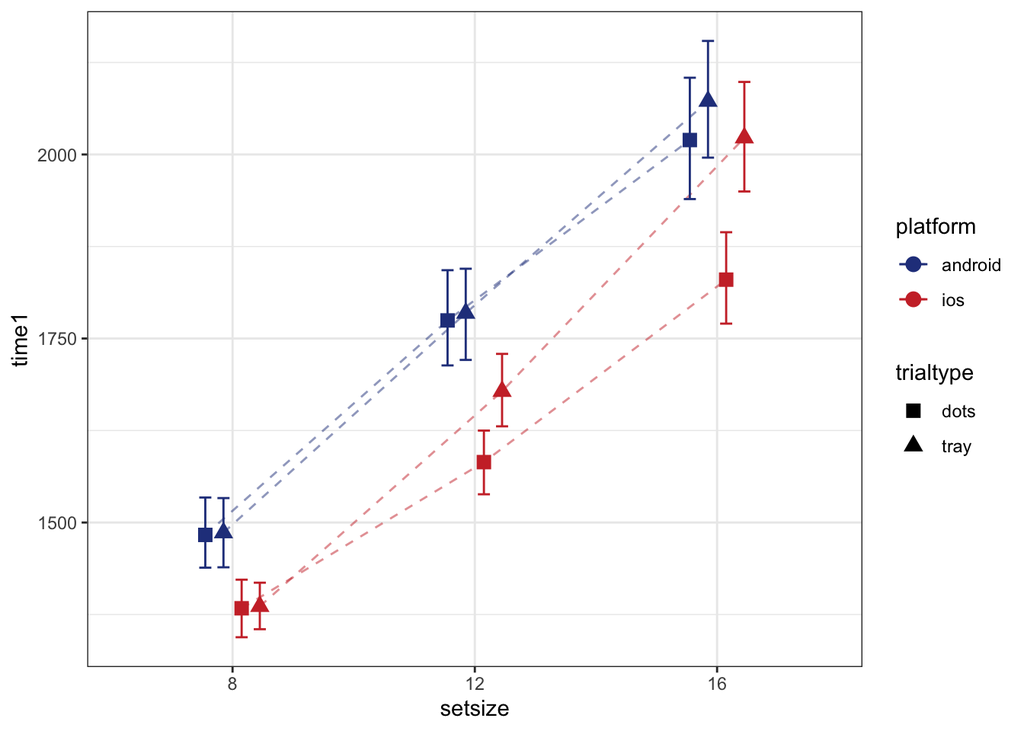

```r
pd <- position_dodge(.3)
share %>%
  filter(trialtype != 'both') %>%
  ggplot(aes(setsize, time1, group = interaction(trialtype, platform), color = platform, shape = trialtype)) +
    stat_summary(fun.y = mean, geom = 'line', linetype = 'dashed', position = pd, alpha = .5) +
  stat_summary(fun.data = mean_cl_boot, geom = 'errorbar', width = .2, position = pd) +
  stat_summary(fun.y = mean, geom = 'point', size = 3, position = pd) +
  theme_bw() +
  scale_color_manual(values = c('royalblue4', 'brown3')) +
  scale_shape_manual(values = c(15, 17))
```

Форма задается через числовой вектор. Какая цифра какую форму обозначает можно найти [тут](https://github.com/angelgardt/mk_ggplot2/blob/master/color_in_hex%2Bshapes%2Blinetypes.pdf).

Вот теперь во истину круто!

## Тема

## Последние штрихи

# Графики со встроенной статистической обработкой

## Статы (stat_)

# Сохранение графиков

## В объект

### Несколько графиков на одной картинке

## В файл

# Добавляем детали

# References